# E-Commerce Customer Behaviour Analysis and Purchase Prediction Using R

Introduction to Data Science: Case Study Report

Siri Jeendru

2026-10-25

# 1 Case Study Overview

**Problem.** An e-commerce website records every visitor session: which pages were opened, how long the visitor stayed, and whether they left quickly. Most sessions do not end in a purchase. The business wants to know which session behaviours are associated with buying, and whether a simple model can predict if a session will end in a purchase.

**Background.** Every visit leaves behavioural clues such as product pages viewed, time spent, bounce and exit rates, visitor type and month. Data science can turn these clues into patterns and a yes/no purchase prediction that helps a business improve its pages and plan offers.

**Objectives**

1. Analyze online shopper session behaviour using the dataset.
2. Identify behavioural factors associated with purchase completion.
3. Visualize patterns between session characteristics and the purchase outcome.
4. Develop and evaluate a Logistic Regression model that predicts whether a session results in a purchase.

**What we predict.** The target is `Revenue`: `TRUE` if the session ended in a purchase, `FALSE` otherwise. It is a yes/no (binary) outcome, not an amount of money.

# 2 Dataset

- **Name:** Online Shoppers Purchasing Intention Dataset
- **Source:** UCI Machine Learning Repository (Sakar & Kastro, 2018), https://doi.org/10.24432/C5F88Q
- **Size:** 12,330 sessions (rows) and 18 variables (columns). One row is one shopping session.
- **Target:** `Revenue` (purchase made: TRUE / FALSE)

**Why it suits this case study:** it records real online shopping sessions, contains behavioural variables, and its target directly records whether a purchase happened. That makes it suitable for both behaviour analysis and binary purchase prediction.

```
## [1] 12330    18
```

| Administrative | Administrative_Duration | Informational | Informational_Duration | ProductRelated | ProductRelated_Duration | BounceRates | ExitRates | PageValues |
| --- | --- | --- | --- | --- | --- | --- | --- | --- |
| 0 | 0 | 0 | 0 | 1 | 0.000000 | 0.2000000 | 0.2000000 | 0 |
| 0 | 0 | 0 | 0 | 2 | 64.000000 | 0.0000000 | 0.1000000 | 0 |
| 0 | 0 | 0 | 0 | 1 | 0.000000 | 0.2000000 | 0.2000000 | 0 |
| 0 | 0 | 0 | 0 | 2 | 2.666667 | 0.0500000 | 0.1400000 | 0 |
| 0 | 0 | 0 | 0 | 10 | 627.500000 | 0.0200000 | 0.0500000 | 0 |
| 0 | 0 | 0 | 0 | 19 | 154.216667 | 0.0157895 | 0.0245614 | 0 |

| Variable | R_type | Example |
| --- | --- | --- |
| Administrative | integer | 0 |
| Administrative_Duration | numeric | 0 |
| Informational | integer | 0 |
| Informational_Duration | numeric | 0 |
| ProductRelated | integer | 1 |
| ProductRelated_Duration | numeric | 0 |
| BounceRates | numeric | 0.2 |
| ExitRates | numeric | 0.2 |
| PageValues | numeric | 0 |
| SpecialDay | numeric | 0 |
| Month | character | Feb |
| OperatingSystems | integer | 1 |
| Browser | integer | 1 |
| Region | integer | 1 |
| TrafficType | integer | 1 |
| VisitorType | character | Returning_Visitor |
| Weekend | logical | FALSE |
| Revenue | logical | FALSE |

**Important variables.** `Administrative`, `Informational` and `ProductRelated` count the pages of each type viewed, and their `_Duration` columns give the time spent on them. `BounceRates`, `ExitRates` and `PageValues` are Google Analytics measures for the pages visited. `SpecialDay` measures closeness to a special day such as Valentine’s Day. `Month`, `VisitorType` and `Weekend` describe when and by whom the visit was made. `OperatingSystems`, `Browser`, `Region` and `TrafficType` are stored as numbers but are really category codes.

# 3 Data Preparation

## 3.1 Missing values

```
##          Administrative Administrative_Duration           Informational
##                       0                       0                       0
##  Informational_Duration          ProductRelated ProductRelated_Duration
##                       0                       0                       0
##             BounceRates               ExitRates              PageValues
##                       0                       0                       0
##              SpecialDay                   Month        OperatingSystems
##                       0                       0                       0
##                 Browser                  Region             TrafficType
##                       0                       0                       0
##             VisitorType                 Weekend                 Revenue
##                       0                       0                       0
```

The dataset has **0 missing values**, which matches the information on the UCI page. No imputation is needed.

## 3.2 Duplicate rows

```
## [1] 125
```

|  | ProductRelated | ProductRelated_Duration | BounceRates | ExitRates | PageValues | Revenue |
| --- | --- | --- | --- | --- | --- | --- |
| 159 | 1 | 0 | 0.2 | 0.2 | 0 | FALSE |
| 160 | 1 | 0 | 0.2 | 0.2 | 0 | FALSE |
| 179 | 1 | 0 | 0.2 | 0.2 | 0 | FALSE |
| 419 | 1 | 0 | 0.2 | 0.2 | 0 | FALSE |
| 457 | 1 | 0 | 0.2 | 0.2 | 0 | FALSE |
| 484 | 1 | 0 | 0.2 | 0.2 | 0 | FALSE |

```
##
## FALSE
##   125
```

```
## [1] 118
```

**Decision: duplicates are kept, not removed.** There are 125 duplicate rows. All of them are non-purchase sessions with bounce and exit rate 0.2, and almost all are one-page visits with no time recorded. UCI states that each session belongs to a different user. So these rows most likely are *different* visitors whose very short visits happened to produce identical values, not copying errors. Removing them would hide real (and common) quick-exit behaviour. Section 5.8 checks that keeping them does not change the conclusions.

## 3.3 Numerical variables and value ranges

| Variable | Min | Median | Mean | Max |
| --- | --- | --- | --- | --- |
| Administrative | 0 | 1.0000000 | 2.32 | 27.0000 |
| Administrative_Duration | 0 | 7.5000000 | 80.82 | 3398.7500 |
| Informational | 0 | 0.0000000 | 0.50 | 24.0000 |
| Informational_Duration | 0 | 0.0000000 | 34.47 | 2549.3750 |
| ProductRelated | 0 | 18.0000000 | 31.73 | 705.0000 |
| ProductRelated_Duration | 0 | 598.9369047 | 1194.75 | 63973.5222 |
| BounceRates | 0 | 0.0031125 | 0.02 | 0.2000 |
| ExitRates | 0 | 0.0251564 | 0.04 | 0.2000 |
| PageValues | 0 | 0.0000000 | 5.89 | 361.7637 |
| SpecialDay | 0 | 0.0000000 | 0.06 | 1.0000 |
| OperatingSystems | 1 | 2.0000000 | 2.12 | 8.0000 |
| Browser | 1 | 2.0000000 | 2.36 | 13.0000 |
| Region | 1 | 3.0000000 | 3.15 | 9.0000 |
| TrafficType | 1 | 2.0000000 | 4.07 | 20.0000 |

```
## [1] 0.0 0.2
```

```
## [1] 0.0 0.2
```

```
## [1]   0.0000 361.7637
```

```
## [1] FALSE
```

No incorrect values were found: bounce and exit rates lie between 0 and 1, and no duration is negative. Several variables (durations, `PageValues`) are strongly **right-skewed**: most sessions have small values and a few have very large values. These large values are plausible (for example, a long shopping session), so they are kept as they are, and no transformation was applied.

## 3.4 Converting categorical variables to factors

```
## 'data.frame':    12330 obs. of  18 variables:
##  $ Administrative         : int  0 0 0 0 0 0 0 1 0 0 ...
##  $ Administrative_Duration: num  0 0 0 0 0 0 0 0 0 0 ...
##  $ Informational          : int  0 0 0 0 0 0 0 0 0 0 ...
##  $ Informational_Duration : num  0 0 0 0 0 0 0 0 0 0 ...
##  $ ProductRelated         : int  1 2 1 2 10 19 1 0 2 3 ...
##  $ ProductRelated_Duration: num  0 64 0 2.67 627.5 ...
##  $ BounceRates            : num  0.2 0 0.2 0.05 0.02 ...
##  $ ExitRates              : num  0.2 0.1 0.2 0.14 0.05 ...
##  $ PageValues             : num  0 0 0 0 0 0 0 0 0 0 ...
##  $ SpecialDay             : num  0 0 0 0 0 0 0.4 0 0.8 0.4 ...
##  $ Month                  : Factor w/ 10 levels "Aug","Dec","Feb",..: 3 3 3 3 3 3 3 3 3 3 ...
##  $ OperatingSystems       : Factor w/ 8 levels "1","2","3","4",..: 1 2 4 3 3 2 2 1 2 2 ...
##  $ Browser                : Factor w/ 13 levels "1","2","3","4",..: 1 2 1 2 3 2 4 2 2 4 ...
##  $ Region                 : Factor w/ 9 levels "1","2","3","4",..: 1 1 9 2 1 1 3 1 2 1 ...
##  $ TrafficType            : Factor w/ 20 levels "1","2","3","4",..: 1 2 3 4 4 3 3 5 3 2 ...
##  $ VisitorType            : Factor w/ 3 levels "New_Visitor",..: 3 3 3 3 3 3 3 3 3 3 ...
##  $ Weekend                : Factor w/ 2 levels "FALSE","TRUE": 1 1 1 1 2 1 1 2 1 1 ...
##  $ Revenue                : Factor w/ 2 levels "FALSE","TRUE": 1 1 1 1 1 1 1 1 1 1 ...
```

Note: `Month` has only 10 levels because the dataset contains no January or April sessions. `June` is written in full while the other months are abbreviated; this is how the data comes from UCI.

# 4 Data Analysis and Visualization

## 4.1 Purchase vs non-purchase sessions

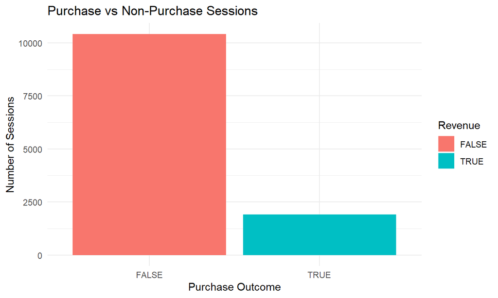

| Revenue | Sessions | Percent |
| --- | --- | --- |
| FALSE | 10422 | 84.53 |
| TRUE | 1908 | 15.47 |

**Interpretation:** only 15.47% of sessions end in a purchase. The classes are **imbalanced**, so accuracy alone can be misleading: a model that always predicts “no purchase” would already be about 85% accurate. That is why precision, recall and F1-score are also reported in Section 5.

## 4.2 Bounce rate and exit rate

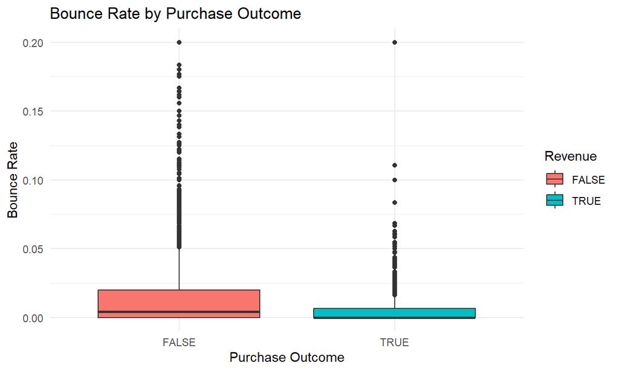

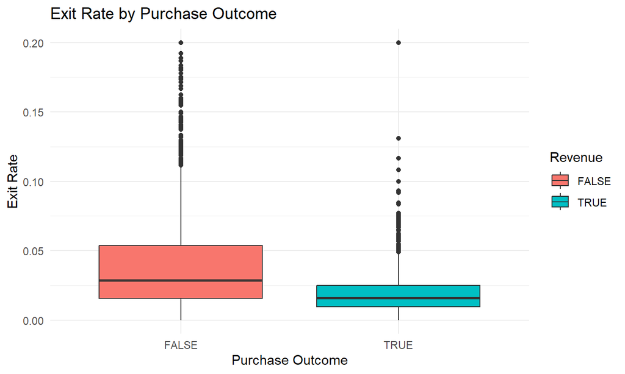

| Revenue | Median_BounceRate | Mean_BounceRate | Median_ExitRate | Mean_ExitRate |
| --- | --- | --- | --- | --- |
| FALSE | 0.0043 | 0.0253 | 0.0286 | 0.0474 |
| TRUE | 0.0000 | 0.0051 | 0.0160 | 0.0196 |

**Interpretation:** sessions that end in a purchase have clearly **lower bounce and exit rates** (mean exit rate 0.0196 for purchases vs 0.0474 for non-purchases). The points above the boxes are sessions with unusually high rates. At the maximum value of 0.2 (visitors who left almost immediately) there are 697 non-purchase sessions but only 3 purchase session(s).

## 4.3 Purchase outcome by visitor type

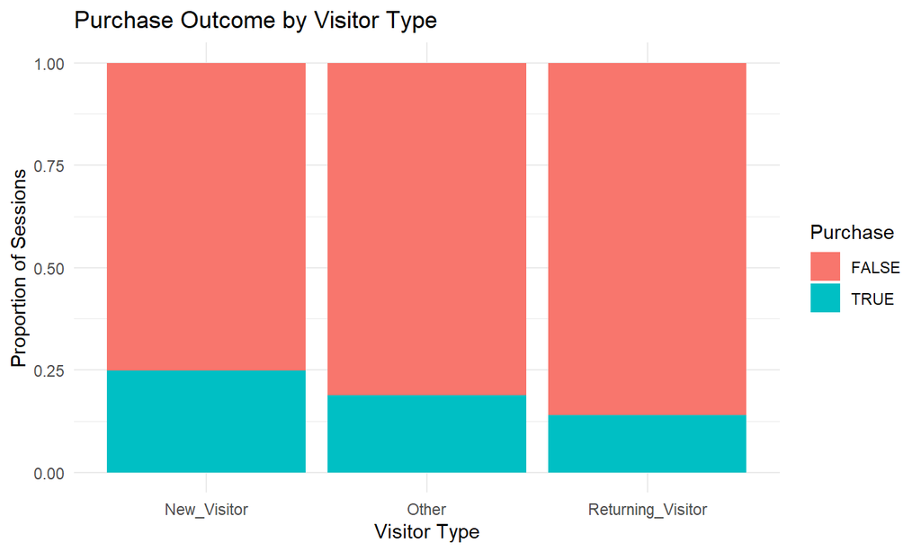

| VisitorType | Purchase_Proportion | Sessions |
| --- | --- | --- |
| New_Visitor | 0.2491 | 1694 |
| Other | 0.1882 | 85 |
| Returning_Visitor | 0.1393 | 10551 |

**Interpretation:** new visitors buy in a larger share of their sessions (24.9%) than returning visitors (13.9%), although returning visitors make up most sessions. The “Other” group is very small (85 sessions), so its proportion is less reliable.

## 4.4 Purchase rate by month *(added)*

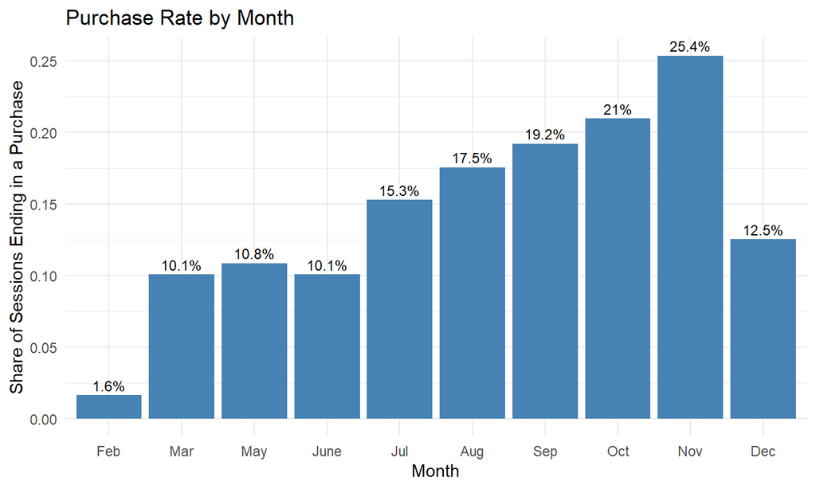

| Month | Sessions | Purchase_Rate |
| --- | --- | --- |
| Feb | 184 | 0.0163 |
| Mar | 1907 | 0.1007 |
| May | 3364 | 0.1085 |
| June | 288 | 0.1007 |
| Jul | 432 | 0.1528 |
| Aug | 433 | 0.1755 |
| Sep | 448 | 0.1920 |
| Oct | 549 | 0.2095 |
| Nov | 2998 | 0.2535 |
| Dec | 1727 | 0.1251 |

**Interpretation:** the purchase rate is highest in **Nov** (25.4%) and lowest in **Feb** (1.6%). The number of sessions also differs a lot between months, so months with few sessions should be read with care.

## 4.5 Correlation between numerical variables *(added)*

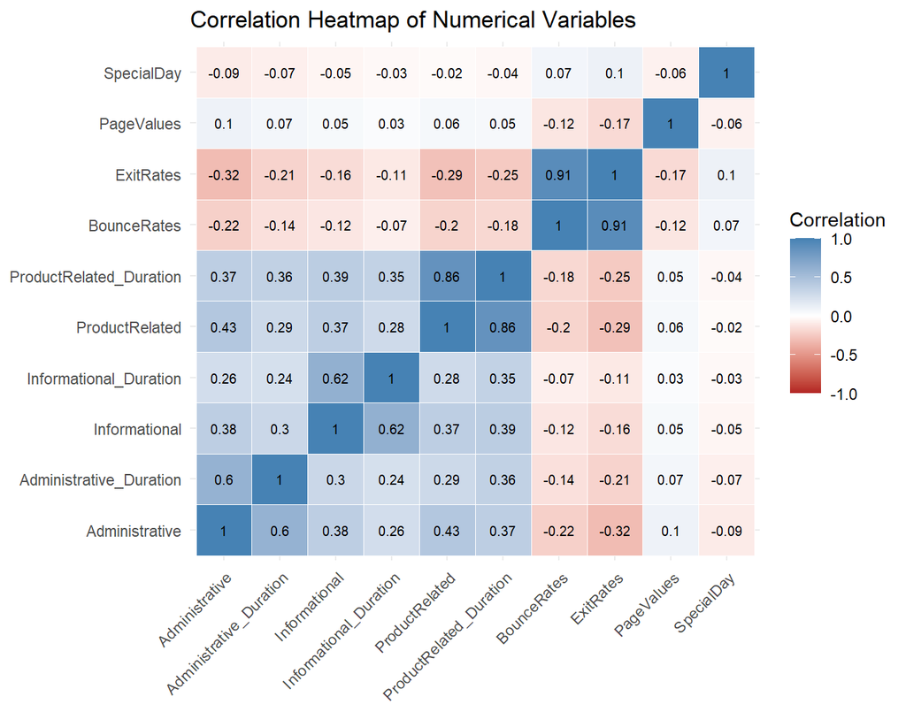

**Interpretation:** each page count is strongly correlated with its own duration (for example `ProductRelated` vs `ProductRelated_Duration`: r = 0.86), and `BounceRates` is strongly correlated with `ExitRates` (r = 0.91). These pairs carry overlapping information. Logistic Regression can still be fitted, but the individual coefficients of correlated variables should be interpreted with care.

# 5 Prediction / Model

## 5.1 Method and why it is suitable

The target `Revenue` has two outcomes, so this is a **binary classification** problem. **Logistic Regression** (`glm()` with `family = binomial`) is used because it:

- predicts the **probability** (0 to 1) that a session ends in a purchase;
- is a standard, well-understood method for yes/no targets;
- is simple and **interpretable**: each coefficient shows whether a variable raises or lowers the chance of purchase.

A probability is turned into a prediction using a **threshold**: if the probability is at or above the threshold, the prediction is `TRUE` (purchase).

## 5.2 Training and testing sets

```
## [1] 9864
```

```
## [1] 2466
```

## 5.3 Model training

The model uses the 10 numerical behaviour variables plus `Month`, `VisitorType` and `Weekend`, exactly as in the original script. `OperatingSystems`, `Browser`, `Region` and `TrafficType` are **not** used: they are technical codes with many rare values (some codes appear only once or twice), which can make `predict()` fail when a code appears in the test set but not in the training set.

| Term | Estimate | Std_Error | z_value | p_value | Odds_Ratio | Significant |
| --- | --- | --- | --- | --- | --- | --- |
| (Intercept) | -1.789e+00 | 0.2025000 | -8.8330 | 0.0000000 | 0.1671000 | Yes (p < 0.05) |
| Administrative | -5.445e-03 | 0.0124300 | -0.4382 | 0.6612000 | 0.9946000 | No |
| Administrative_Duration | 1.377e-04 | 0.0002165 | 0.6363 | 0.5246000 | 1.0000000 | No |
| Informational | 6.478e-03 | 0.0303700 | 0.2133 | 0.8311000 | 1.0060000 | No |
| Informational_Duration | 1.695e-04 | 0.0002427 | 0.6984 | 0.4849000 | 1.0000000 | No |
| ProductRelated | 1.063e-03 | 0.0013730 | 0.7748 | 0.4385000 | 1.0010000 | No |
| ProductRelated_Duration | 8.720e-05 | 0.0000331 | 2.6330 | 0.0084720 | 1.0000000 | Yes (p < 0.05) |
| BounceRates | -4.338e+00 | 3.7810000 | -1.1470 | 0.2513000 | 0.0130600 | No |
| ExitRates | -1.614e+01 | 2.7310000 | -5.9090 | 0.0000000 | 0.0000001 | Yes (p < 0.05) |
| PageValues | 8.472e-02 | 0.0027420 | 30.9000 | 0.0000000 | 1.0880000 | Yes (p < 0.05) |
| SpecialDay | -1.667e-01 | 0.2653000 | -0.6281 | 0.5299000 | 0.8465000 | No |
| MonthDec | -5.077e-01 | 0.2083000 | -2.4370 | 0.0148000 | 0.6019000 | Yes (p < 0.05) |
| MonthFeb | -1.481e+00 | 0.6591000 | -2.2480 | 0.0245900 | 0.2273000 | Yes (p < 0.05) |
| MonthJul | 2.275e-01 | 0.2457000 | 0.9260 | 0.3544000 | 1.2550000 | No |
| MonthJune | -2.442e-01 | 0.3118000 | -0.7833 | 0.4335000 | 0.7833000 | No |
| MonthMar | -4.273e-01 | 0.2063000 | -2.0720 | 0.0382900 | 0.6523000 | Yes (p < 0.05) |
| MonthMay | -4.923e-01 | 0.1992000 | -2.4710 | 0.0134800 | 0.6112000 | Yes (p < 0.05) |
| MonthNov | 6.307e-01 | 0.1868000 | 3.3770 | 0.0007335 | 1.8790000 | Yes (p < 0.05) |
| MonthOct | -4.766e-03 | 0.2325000 | -0.0205 | 0.9836000 | 0.9952000 | No |
| MonthSep | 3.217e-02 | 0.2435000 | 0.1321 | 0.8949000 | 1.0330000 | No |
| VisitorTypeOther | -5.037e-01 | 0.6024000 | -0.8361 | 0.4031000 | 0.6043000 | No |
| VisitorTypeReturning_Visitor | -3.233e-01 | 0.0975600 | -3.3140 | 0.0009211 | 0.7238000 | Yes (p < 0.05) |
| WeekendTRUE | 1.383e-01 | 0.0790500 | 1.7500 | 0.0801400 | 1.1480000 | No |

**Interpretation:** the significant variables (p < 0.05) are ProductRelated_Duration, ExitRates, PageValues, MonthDec, MonthFeb, MonthMar, MonthMay, MonthNov, VisitorTypeReturning_Visitor. `PageValues` is a strong positive predictor: each 1-unit increase multiplies the odds of purchase by about 1.088. `ExitRates` has a strong negative effect. Month coefficients are compared with the reference month (Aug, the first level alphabetically).

## 5.4 Prediction on the test data

```
##     4     8    19    22    23    28    29    34    40    42
## 0.002 0.001 0.005 0.000 0.016 0.004 0.012 0.006 0.020 0.008
```

```
##       4       8      19      22      23      28      29      34      40      42
## "FALSE" "FALSE" "FALSE" "FALSE" "FALSE" "FALSE" "FALSE" "FALSE" "FALSE" "FALSE"
```

## 5.5 Evaluation at the standard threshold 0.50

```
##        Predicted
## Actual  FALSE TRUE
##   FALSE  2029   61
##   TRUE    241  135
```

```
## Accuracy: 87.75 %
```

```
## Precision: 68.88 %
```

```
## Recall: 35.9 %
```

```
## F1-score: 47.2 %
```

At 0.50 the model is accurate overall but finds only 35.9% of the real purchases (135 of 376). Because purchases are rare, the predicted probabilities are usually low, and a 0.50 cut-off misses many buyers. A **lower threshold** catches more buyers.

## 5.6 Choosing a lower threshold

To compare thresholds without repeating code, the same calculation as above is put into one small function.

**Original approach (exploratory).** The original script also tried a threshold of **0.30**. That value was chosen *after looking at the test-set results*. Once the test set has been used to choose a setting, it is no longer an independent check, so the 0.30 result is likely to be slightly optimistic.

**Revised approach (used for the final result).** The threshold is chosen using the **training data only**: we try thresholds from 0.05 to 0.95 and keep the one with the highest F1-score on the training sessions. The test set is then used **once** to evaluate that choice.

```
## Threshold with the highest training F1-score: 0.25
```

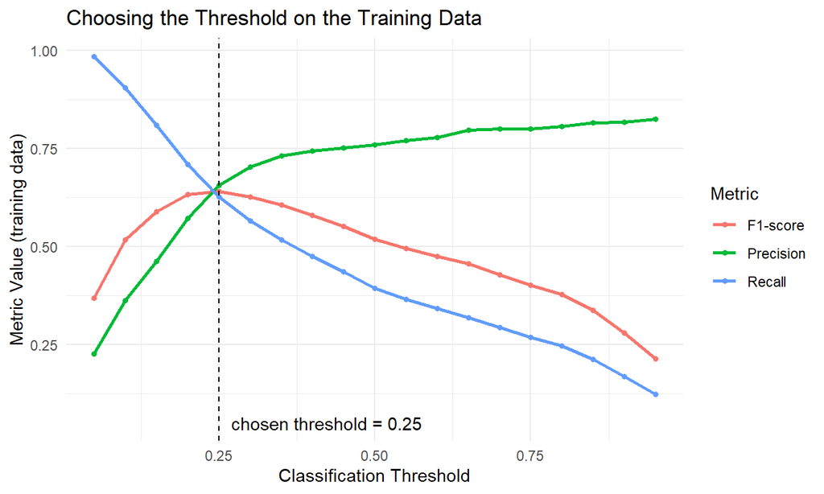

**Interpretation:** lowering the threshold raises recall (more buyers found) but lowers precision (more false alarms). F1-score balances the two and is highest on the training data at **0.25**.

| Approach | Threshold | Accuracy | Precision | Recall | F1_score |
| --- | --- | --- | --- | --- | --- |
| Original: standard threshold | 0.50 | 87.75 | 68.88 | 35.90 | 47.20 |
| Original: exploratory (chosen on test) | 0.30 | 88.65 | 65.79 | 53.19 | 58.82 |
| Revised: chosen on training data | 0.25 | 87.75 | 60.39 | 57.18 | 58.74 |

```
##        Predicted
## Actual  FALSE TRUE
##   FALSE  1949  141
##   TRUE    161  215
```

All values above are percentages on the 2466 test sessions. `model_evaluation_results.csv` is saved in the project folder. It now also records which threshold and approach each row belongs to; the original file stored only the 0.30 row.

## 5.7 Prediction plot

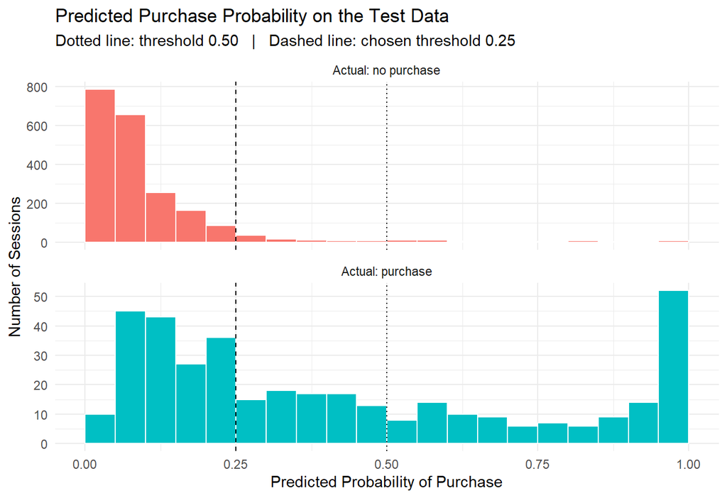

**Interpretation:** most non-purchase sessions receive probabilities close to 0, which is why accuracy is high. Many real purchase sessions fall **between** the two lines; moving the threshold from 0.50 down to 0.25 turns these into correct “purchase” predictions, which is why recall improves.

## 5.8 Robustness checks *(added)*

Two checks test whether the conclusions depend on decisions made earlier. Each uses the same steps as the main model: 80/20 split with `set.seed(123)`, threshold chosen on training data, one evaluation on the test data.

| Model | Threshold | Accuracy | Precision | Recall | F1_score |
| --- | --- | --- | --- | --- | --- |
| Main model (duplicates kept) | 0.25 | 87.75 | 60.39 | 57.18 | 58.74 |
| Duplicates removed | 0.25 | 88.73 | 64.86 | 64.36 | 64.61 |
| Without PageValues | 0.20 | 71.05 | 28.77 | 60.90 | 39.08 |

A single split can move the numbers by a few points, depending on which sessions land in the test set. To separate that effect from the duplicate decision, the full procedure is repeated with 30 different random splits (seeds 1 to 30).

| Data | Mean_F1 | Min_F1 | Max_F1 |
| --- | --- | --- | --- |
| Duplicates kept | 63.05 | 57.71 | 65.96 |
| Duplicates removed | 62.31 | 58.19 | 66.84 |

| PageValues_group | Sessions | Purchase_Rate |
| --- | --- | --- |
| PageValues = 0 | 9600 | 0.0385 |
| PageValues > 0 | 2730 | 0.5634 |

**Interpretation:**

- **Duplicates:** in the single split above, the F1-score is 58.74% with duplicates kept and 64.61% with them removed. Averaged over 30 different splits, the two are almost the same (63.05% vs 62.31%). The gap in the single split therefore comes from *which sessions land in the test set*, not from the duplicates, and keeping them does not change the conclusions.
- **Split-to-split variation:** across the 30 splits, the main model’s F1-score ranges from 57.71% to 65.96%. The reported result with `set.seed(123)` (58.74%) lies inside this range, towards its lower end, so it is not an unusually lucky split.
- **PageValues:** without `PageValues`, the F1-score drops sharply, so this one variable carries most of the predictive power. Google Analytics calculates a page’s value from purchases that happened after visitors viewed that page. The value may therefore partly reflect the purchase itself, and might not be fully known early in a session. The main model’s results should be read as **an upper estimate** of what a real-time system could achieve.

# 6 Results and Conclusion

## 6.1 Key findings

- Only 15.47% of 12,330 sessions end in a purchase; the data is imbalanced.
- Purchasing sessions have **lower bounce and exit rates** and much **higher page values**: 56.3% of sessions with a positive page value end in a purchase, against 3.9% of the rest.
- **New visitors** convert at a higher rate than returning visitors.
- The purchase rate varies by **month**, highest in Nov.

## 6.2 Model results (test data, 2466 sessions)

```
## Total sessions: 12330
```

```
## Total variables: 18
```

```
## Training sessions: 9864
```

```
## Testing sessions: 2466
```

```
## Chosen threshold (from training data): 0.25
```

```
## Accuracy: 87.75 %
```

```
## Precision: 60.39 %
```

```
## Recall: 57.18 %
```

```
## F1-score: 58.74 %
```

With the threshold chosen on the training data, the Logistic Regression model reaches an accuracy of 87.75% and an F1-score of 58.74% on unseen test sessions. It finds 57.2% of real purchases, compared with 35.9% at the standard 0.50 threshold. This revised F1-score is very close to the original exploratory result at 0.30 (58.82%), which supports the decision to use a lower threshold.

## 6.3 Recommendations

1. **Reduce early exits.** High exit and bounce rates go with non-purchase; improving landing pages and navigation could keep more visitors in the session.
2. **Focus on high-value pages.** Sessions that reach pages with a positive page value are far more likely to buy; guide visitors towards these pages (product details, cart, offers).
3. **Win back returning visitors.** Returning visitors buy less often per session; reminders or personalised offers may raise their conversion.
4. **Plan by season.** Use the monthly differences to time campaigns and stock.

## 6.4 Limitations

- **Threshold selection:** the final threshold is chosen on the training data, so it is slightly fitted to that data. A separate validation set or cross-validation would be stricter. The original 0.30 result was chosen on the test set and is exploratory only.
- **Single random split:** the main results come from one 80/20 split (`set.seed(123)`). Other splits give F1-scores between 57.71% and 65.96% (Section 5.8).
- **PageValues:** it may partly reflect the purchase itself (Section 5.8), so performance may be optimistic for real-time prediction.
- **Duplicates:** 125 identical rows were kept (Section 3.2); some of them fall into both the training and test sets.
- **Scope:** the data covers one year of one online store, so findings may not apply to other websites. Logistic Regression assumes a linear relationship on the log-odds scale and may miss more complex patterns.

## 6.5 Conclusion

Session behaviour, especially page value, exit rate and visitor type, is clearly associated with whether an online shopping session ends in a purchase. A simple, interpretable Logistic Regression model built in R predicts purchases with high accuracy. Choosing a lower threshold on the training data greatly improves how many buyers it finds. All results in this report are produced by the R code above from the original UCI dataset.

# 7 References

1. Sakar, C. O., & Kastro, Y. (2018). *Online Shoppers Purchasing Intention Dataset* Dataset. UCI Machine Learning Repository. https://doi.org/10.24432/C5F88Q
2. Sakar, C. O., Polat, S. O., Katircioglu, M., & Kastro, Y. (2019). Real-time prediction of online shoppers’ purchasing intention using multilayer perceptron and LSTM recurrent neural networks. *Neural Computing and Applications, 31*(10), 6893–6908. https://doi.org/10.1007/s00521-018-3523-0
3. R Core Team. *R: A Language and Environment for Statistical Computing* (R version 4.6.1 (2026-06-24 ucrt)). R Foundation for Statistical Computing, Vienna, Austria. https://www.R-project.org/
4. Wickham, H. (2016). *ggplot2: Elegant Graphics for Data Analysis*. Springer-Verlag New York. (package version 4.0.3)
5. Wickham, H., François, R., Henry, L., Müller, K., & Vaughan, D. *dplyr: A Grammar of Data Manipulation*. R package version 1.2.1. https://CRAN.R-project.org/package=dplyr
6. Allaire, J. J., Xie, Y., et al. *rmarkdown: Dynamic Documents for R*. R package version 2.32. https://CRAN.R-project.org/package=rmarkdown